# Your Digest for Monday, Feb 26, 2024 12:59 PM

- Majority occurs in the GI system, *particularly in the small intestine*.

Bradykinin and histamine are also released in smaller amounts by NETS.

**Diagnosis**:

- Initial test is 24 hour **urinary 5-hydroxyindoleacetic acid**. (5-HIAA)
  - Foods containing serotonin (banana, pineapple, avocado, tomato, avocado) etc should be avoided.
- Also **plasma chromogranin A y**
- Can also use plasma level of 5-hydroxyindoleacetic acid.

**Management**:

- For temporary symptomatic relief while waiting for surgical treatment -> **octreotide**; somatostatin analog which act on the neutroendocrine cell somatostatin receptors and **inhibit serotonin release**.
- Somatostain itself has a short half life lasting minutes. Octreotide and other analogs have been made to have longer half lives (upto 2 hours) [Source](https://www.ncbi.nlm.nih.gov/pmc/articles/PMC6627451/)
- Some actions of somatostatin (and octreotide) (From notes search results)
  - Inhibits GH secretion
  - Causes splanchnic vasoconstriction
  - Inhibits gastric acid secretion
  - Antagonizes effects of sulfonylurea.
  - Symptomatic management of carcinoid syndrome.
- The variety of actions of somatostatin can be explained by the **tissue distribution of the 5 types of somatostatin receptor**.

> [!INFO] Background info on Serotonin: Skip

> > It has been known since the mid-nineteenth century that after blood clots the resulting serum possesses a substance that constricts vascular smooth muscle so as to increase vascular tone. Around the turn of this century, platelets were identified as the source of this substance. In the late 1940s, Rapport and collaborators [1] isolated, purified and identified this “tonic” substance in “serum” (hence, serotonin) as the substituted indole 5-hydroxytryptamine  
> > Platelets don't synthesize their own serotonin; they **actively** take it up from plasma.  
> > [Source](https://www.ncbi.nlm.nih.gov/books/NBK28150/)

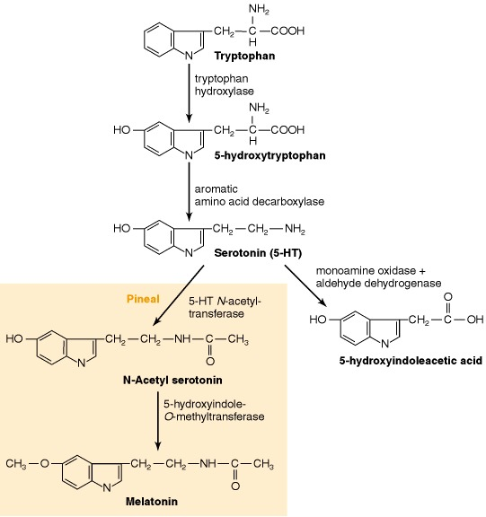

- *Acquired* thrombophilia
- Female to male ratio of about 3.5:1.[Source](https://pubmed.ncbi.nlm.nih.gov/35860235/)
- Increased risk of recurrent VTE
- Can occur as a primary disorder or secondary to other conditions - most commonly SLE.
- aPL antibodies *activate various cells* stimulates procoagulant activity.
- *Complement* is also activated.
- Both predispose to thrombosis.
- Recurrent foetal *loss < 10 weeks POA* or other unexplained foetal loss
- Antiphospholipid syndrome can cause the **VDRL to be falsely positive!**
- 'Antiphopholipid' antibodies is a misnomer because they are actually antibodies against certain proteins.
- "Antiphospholipid antibodies" is a collective term for several of antibodies including anti cardiolipin antibodies and lupus anticoagulant.
- The most important of these proteins is **anti-beta2 glycprotein I**. (*anti Beta2-GPI*)
- This group also includes *anti-cardiolipin antibodies*.  
  aPL is also directed against a variety of other antigenic targets such as prothrombin (PT), phosphatidylserine/prothrombin (PS/PT) complexes, vimentin/cardiolipin complexes, annexin A2, *lupus anticoagulant* and annexin A5  
  **Lupus anticoagulants**: (a type of antiphopholipid antibody) actually refers to an **anticoagulant effect** of several types of **antibodies**.  
  Management: Anticoagulation during pregnancy.

> Unfractionated heparin is preferred over LMW heparin in patients with severely reduced kidney function because **LMW heparin clearance is exclusively by the kidney**, while elimination of **unfractionated heparin is by the kidney *AND* liver**.

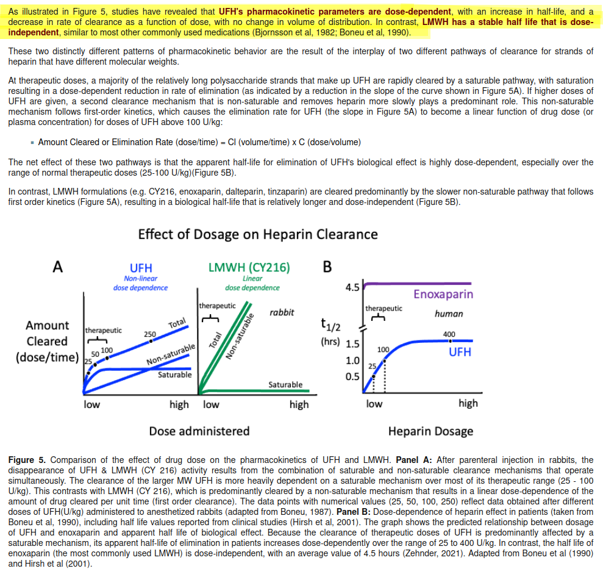

> [Source](https://tmedweb.tulane.edu/pharmwiki/doku.php/heparin_pharmacology)

> [!TIP] vignette:  
> A 25 year old woman at a POA of 25 weeks presents with worsening confusion over two days but has *no fever*. (pentad not present in all)  
> Blood picture shows fragmentation and thrombocytopenia.

> [!INFO] Pathophysiology details: Skip this.  
> ADAMTS degrades the vWF multimers and prevents thrombus formation **particularly in high sheer stress areas** like small arterioles and capillaries. Shear stress leads to a conformational change in the large VWF multimers that exposes the ADAMTS13 cleavage site
- The major cause of severe ADAMTS13 deficiency is **an autoantibody**. Inherited gene mutations account for a minority.
- Patients with ADAMTS13 deficiency usually get TTP when they **encounter a TRIGGER** such as infection or pregnancy.
- This is the dangerous one.
- **50% of deaths occurs in first 24 hours!**

**BUT this full pentad occurs in only 5% of patients**  
| TTP Management | Typical HUS management | Atypical HUS Mx |  
| ---- | ---- | ---- |  
| **1.** Plasmapheresis (reduces mortality from 90% to 20%) **2.** Corticosteroids **3.** PLT transfusion (can increase thrombosis. GIVE ONLY IN SEVERE BLEEDING) | Supportive, Plasmapheresis is *NOT* beneficial | Clinically similar to TTP. Initiate Plasma exchange. If not responding to plasma exhange, consider atypical HUS |  
| | | Eculizuma (anti C5 antibody) is used in treatment) |  
| | Liver transplantation can be curative (as factor H is produced in the liver) | |  
| **No role for IVIG or methylprednisolone** | | |  
| Rituximab for refractory cases | | |

> [!INFO] Plasmapheresis Vs. Plasma exchange  
> Plasmapheresis is the process of separating plasma from blood. Plasma exchange is the process of substituting the separated plasma with another fluid (albumin or donor plasma)  
> [Source](https://hemaware.org/taking-charge/plasmapherisis-vs-therapeutic-plasma-exchange)

# Motor neuron disease and ALS (amyotrophic lateral sclerosis)

- Hallmark is **mixture of upper and lower motor neurons signs**
- **largely clinical.**
- EMG will show denervation of muscles secondary to motor neuron degeneration.
- Electromyography shows a *reduced number of action potentials* with **increased amplitude.**

**FBC:** **raised WBC** is characteristic - passMedicine

- Infection control - Alcohol gel *does not kill C diff spores* -> **HAND WASHING IS ESSENTIAL**

**First pass effect** - drug gets metabolized at a non target organ so that effective dose at the target organ is reduced. Commonest site for this to happen is the **liver**.

| Phase 1 | Phase 2 |
| --- | --- |
| Oxidation, reduction, hydrolysis | Conjugation |
| Yields a polar metabolite | Yields a larger polar metabolite |
| Product may be **active** | Product is inactive |
| Mainly in liver | Mainly in liver |
| CYP450 system enzymes | various other enzymes |
|  | Can act on results of phase I |
| Phase 1 and 2 (some sources also add phase 3) do not necessarily occur in sequence. |  |

phase 1:

- Geriatric patients have reduced phase 1 reaction rates.
- Phase 1 is catalyzed by the *membrane-bound* **cytochrome P450**.

Phase 2: conjugation: eg: glucuronidation, acetylation and sulfation - make a drug *even more soluble* by **conjugation** with another group.

- Acetylation is one example. Patients can be slow or fast acetylators. [[Tuberculosis#Isoniazid]]
- Phase 2 reactions *occur on a metabolite formed by a phase I reaction* that is still not adequately hydrophilic.
- Phase II reactions result in the formation of readily excreted, *less active*,**nontoxic** substances. They are excreted via urine or bile.
- They occur within hepatocytes cytoplasm.

## CYP450 system

Enzymes included in this sytem include the following:  
[Source](https://www.ncbi.nlm.nih.gov/books/NBK544353/)

| Enzyme | Inhibitor | Inducer |
| --- | --- | --- |
| **CYP3A4** | Aprepitant, clarithromycin, erythromycin, fluconazole, grapefruit juice, isoniazid, itraconazole, ketoconazole, metronidazole, telithromycin, valproic acid, voriconazole | Carbamazepine, dexamethasone, oxcarbazepine, phenobarbital, phenytoin, rifampin |
| **CYP2C9/8** | Fluconazole, ibuprofen, indomethacin, isoniazid, ketoconazole, sulfamethoxazole, trimethoprim | Carbamazepine, phenobarbital, phenytoin, rifampin |
| **CYP2D6** | Isoniazid, ketoconazole, methadone, nicardipine |  |
| **CYP2C19** | Fluconazole, ketoconazole, isoniazid, omeprazole | Carbamazepine, phenytoin, rifampin |

# Occulogyric crisis

> **O**culogyric Crisis (OGC) is a form of dystonic movement disorder characterized by paroxysmal, conjugate, and typically upward deviation of the eyeball, which occurs for seconds to hours

Triggers: Neurodegenerative diseases, drugs (antipsychotics, antidepressants, anticonvulsants) etc

Treatment: Antimuscarinic agent like procyclidine, benztropine,